# Tugas Pekan 5 MPDW

Muhammad Farhan Adeva - G1401211062

2023-09-26

#library

```r
library(ggplot2)
library(tsibble)
library(tseries)
library(MASS)
```

# Input Data

```r
library('rio')
datampdw <- import("https://raw.githubusercontent.com/Adevaaaa/MPDW/main/Data_Tugas/Data%20Tugas%20MPDW%201.csv")
```

```r
sepuh <- ts(datampdw$Suhu)
```

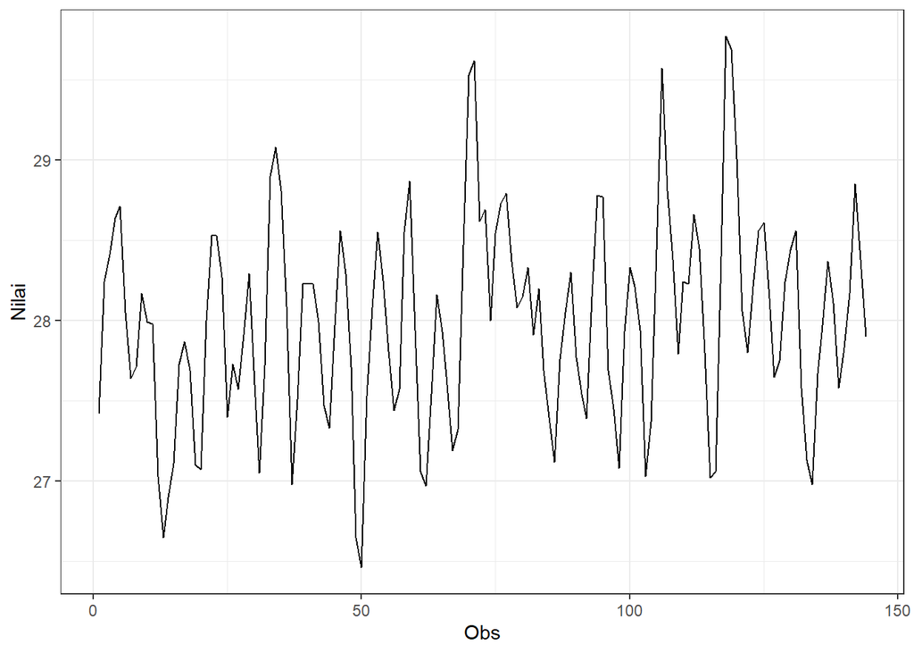

```r
plot_stas <- sepuh |> as_tsibble() |>
  ggplot(aes(x = index, y = value)) + geom_line() + theme_bw() +
  xlab("Obs") + ylab("Nilai")
plot_stas
```

```r
mean(sepuh)
```

```
## [1] 27.99444
```

```r
var(sepuh)
```

```
## [1] 0.4053493
```

Plot deret waktu di atas menunjukkan bahwa data stasioner dalam rataan, ditandai dengan data yang menyebar di sekitar nilai tengahnya (27.99) dan stasioner dalam ragam, ditandai dengan lebar pita yang cenderung sama.

# Plot ACF

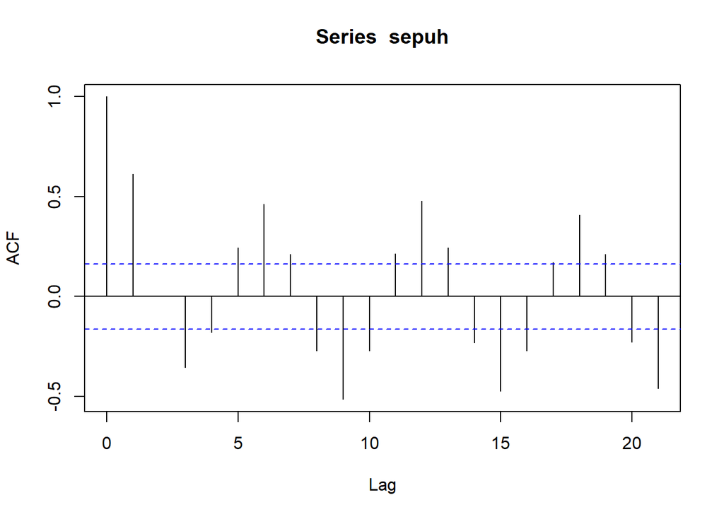

```r
acf(sepuh)
```

Berdasarkan plot ACF, terlihat bahwa plot ACF pada data tersebut cenderung tails off dan membentuk gelombang sinus.

# Uji ADF

```r
tseries::adf.test(sepuh)
```

```
##
##  Augmented Dickey-Fuller Test
##
## data:  sepuh
## Dickey-Fuller = -3.7609, Lag order = 5, p-value = 0.02293
## alternative hypothesis: stationary
```

$H_{0} : $ Data tidak stasioner dalam rataan $H_{1}:$ Data stasioner dalam rataan

Berdasarkan uji ADF tersebut, didapat p-value sebesar 0.02 yang lebih kecil dari taraf nyata 5% sehingga tolak $H_{0}$ dan menandakan bahwa data stasioner dalam rataan. Hal ini sesuai dengan hasil eksplorasi menggunakan plot time series dan plot ACF.

# Plot Box-Cox

```r
n <- length(sepuh)
index <- seq(1:n)
bc <- boxcox(sepuh~index, lambda = seq(-8,4,by=1))
```

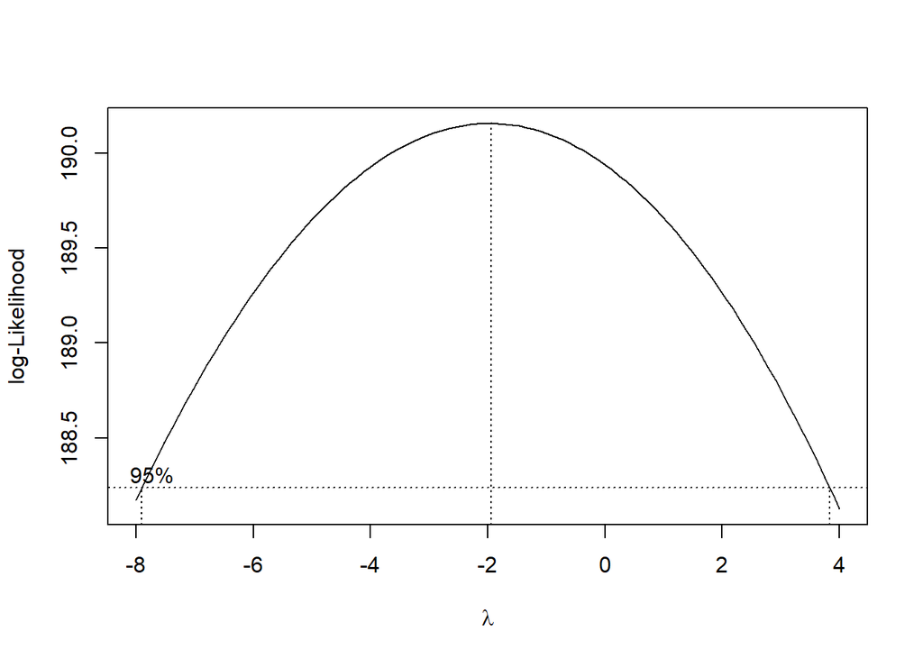

```r
#Nilai Rounded Lambda
lambda <- bc$x[which.max(bc$y)]
lambda
```

```
## [1] -1.939394
```

```r
#Selang Kepercayaan ( Blom  Bener)
bc$x[bc$y > max(bc$y) - 1/2 *qchisq(.95,1)]
```

```
##  [1] -7.8787879 -7.7575758 -7.6363636 -7.5151515 -7.3939394 -7.2727273
##  [7] -7.1515152 -7.0303030 -6.9090909 -6.7878788 -6.6666667 -6.5454545
## [13] -6.4242424 -6.3030303 -6.1818182 -6.0606061 -5.9393939 -5.8181818
## [19] -5.6969697 -5.5757576 -5.4545455 -5.3333333 -5.2121212 -5.0909091
## [25] -4.9696970 -4.8484848 -4.7272727 -4.6060606 -4.4848485 -4.3636364
## [31] -4.2424242 -4.1212121 -4.0000000 -3.8787879 -3.7575758 -3.6363636
## [37] -3.5151515 -3.3939394 -3.2727273 -3.1515152 -3.0303030 -2.9090909
## [43] -2.7878788 -2.6666667 -2.5454545 -2.4242424 -2.3030303 -2.1818182
## [49] -2.0606061 -1.9393939 -1.8181818 -1.6969697 -1.5757576 -1.4545455
## [55] -1.3333333 -1.2121212 -1.0909091 -0.9696970 -0.8484848 -0.7272727
## [61] -0.6060606 -0.4848485 -0.3636364 -0.2424242 -0.1212121  0.0000000
## [67]  0.1212121  0.2424242  0.3636364  0.4848485  0.6060606  0.7272727
## [73]  0.8484848  0.9696970  1.0909091  1.2121212  1.3333333  1.4545455
## [79]  1.5757576  1.6969697  1.8181818  1.9393939  2.0606061  2.1818182
## [85]  2.3030303  2.4242424  2.5454545  2.6666667  2.7878788  2.9090909
## [91]  3.0303030  3.1515152  3.2727273  3.3939394  3.5151515  3.6363636
## [97]  3.7575758
```

# Partisi Data

```r
sepuh1 <- sepuh[1:63] |> ts()
mean(sepuh1)
```

```
## [1] 27.83111
```

```r
var(sepuh1)
```

```
## [1] 0.368852
```

#Plot Time Series

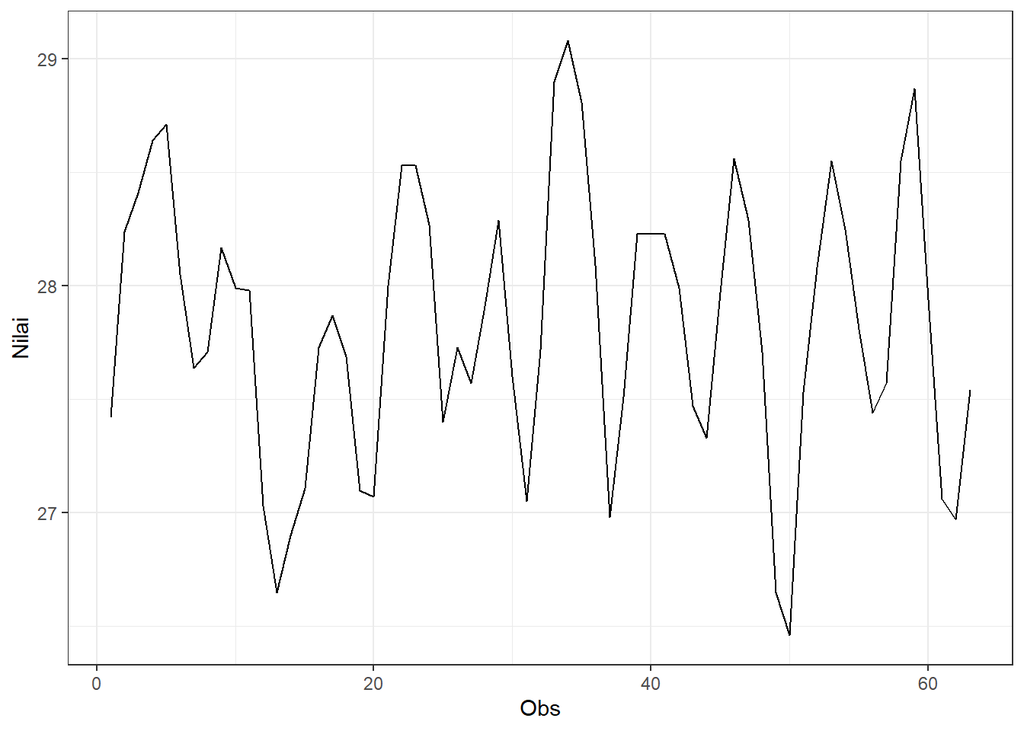

```r
sepuh1 |> as_tsibble() |>
  ggplot(aes(x = index, y = value)) +
  geom_line() + theme_bw() +
  xlab("Obs") + ylab("Nilai")
```

Plot deret waktu di atas menunjukkan bahwa data stasioner dalam rataan, ditandai dengan data yang menyebar di sekitar nilai tengahnya (27.83) dan stasioner dalam ragam, ditandai dengan lebar pita yang cenderung sama.

#Plot ACF

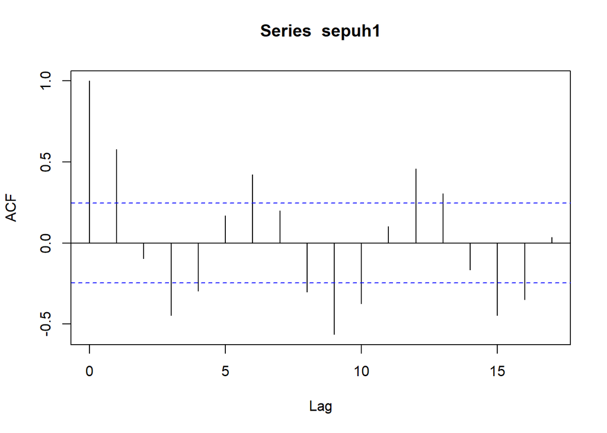

```r
acf(sepuh1)
```

Berdasarkan plot ACF, terlihat bahwa plot ACF pada data tersebut cenderung tails off dan membentuk gelombang sinus.

#Uji ADF

```r
tseries::adf.test(sepuh1)
```

```
##
##  Augmented Dickey-Fuller Test
##
## data:  sepuh1
## Dickey-Fuller = -3.6685, Lag order = 3, p-value = 0.03471
## alternative hypothesis: stationary
```

$H_{0} : $ Data tidak stasioner dalam rataan $H_{1}:$ Data stasioner dalam rataan

Berdasarkan uji ADF tersebut, didapat p-value sebesar 0.03 yang lebih kecil dari taraf nyata 5% sehingga tolak $H_{0}$ dan menandakan bahwa data stasioner dalam rataan. Hal ini sesuai dengan hasil eksplorasi menggunakan plot time series dan plot ACF.

#Plot BoxCox

```r
index <- seq(1:length(sepuh1))
bc1 <- boxcox(sepuh1~index,lambda= seq(-8,15,by=1))
```

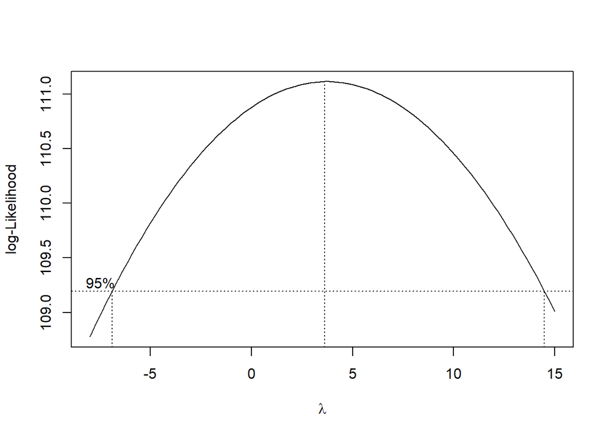

```r
#Nilai Rounded Lambda
lambda1 <- bc1$x[which.max(bc1$y)]
lambda1
```

```
## [1] 3.616162
```

```r
#Selang Kepercayaan
bc$x[bc1$y > max(bc1$y) - 1/2 * qchisq(.95,1)]
```

```
##  [1] -7.3939394 -7.2727273 -7.1515152 -7.0303030 -6.9090909 -6.7878788
##  [7] -6.6666667 -6.5454545 -6.4242424 -6.3030303 -6.1818182 -6.0606061
## [13] -5.9393939 -5.8181818 -5.6969697 -5.5757576 -5.4545455 -5.3333333
## [19] -5.2121212 -5.0909091 -4.9696970 -4.8484848 -4.7272727 -4.6060606
## [25] -4.4848485 -4.3636364 -4.2424242 -4.1212121 -4.0000000 -3.8787879
## [31] -3.7575758 -3.6363636 -3.5151515 -3.3939394 -3.2727273 -3.1515152
## [37] -3.0303030 -2.9090909 -2.7878788 -2.6666667 -2.5454545 -2.4242424
## [43] -2.3030303 -2.1818182 -2.0606061 -1.9393939 -1.8181818 -1.6969697
## [49] -1.5757576 -1.4545455 -1.3333333 -1.2121212 -1.0909091 -0.9696970
## [55] -0.8484848 -0.7272727 -0.6060606 -0.4848485 -0.3636364 -0.2424242
## [61] -0.1212121  0.0000000  0.1212121  0.2424242  0.3636364  0.4848485
## [67]  0.6060606  0.7272727  0.8484848  0.9696970  1.0909091  1.2121212
## [73]  1.3333333  1.4545455  1.5757576  1.6969697  1.8181818  1.9393939
## [79]  2.0606061  2.1818182  2.3030303  2.4242424  2.5454545  2.6666667
## [85]  2.7878788  2.9090909  3.0303030  3.1515152  3.2727273  3.3939394
## [91]  3.5151515  3.6363636
```

# Bagian 2

```r
sepuh2 <- sepuh[1:126]|> ts()
mean(sepuh2)
```

```
## [1] 28.00032
```

```r
var(sepuh2)
```

```
## [1] 0.4310079
```

#Plot Time Series

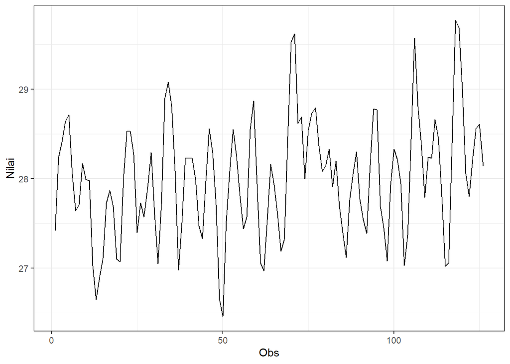

```r
sepuh2|> as_tsibble() |>
  ggplot(aes(x = index, y = value)) +
  geom_line() + theme_bw() +
  xlab("Obs") + ylab("Nilai")
```

Plot deret waktu di atas menunjukkan bahwa data stasioner dalam rataan, ditandai dengan data yang menyebar di sekitar nilai tengahnya (28.00) dan stasioner dalam ragam, ditandai dengan lebar pita yang cenderung sama.

#Plot ACF

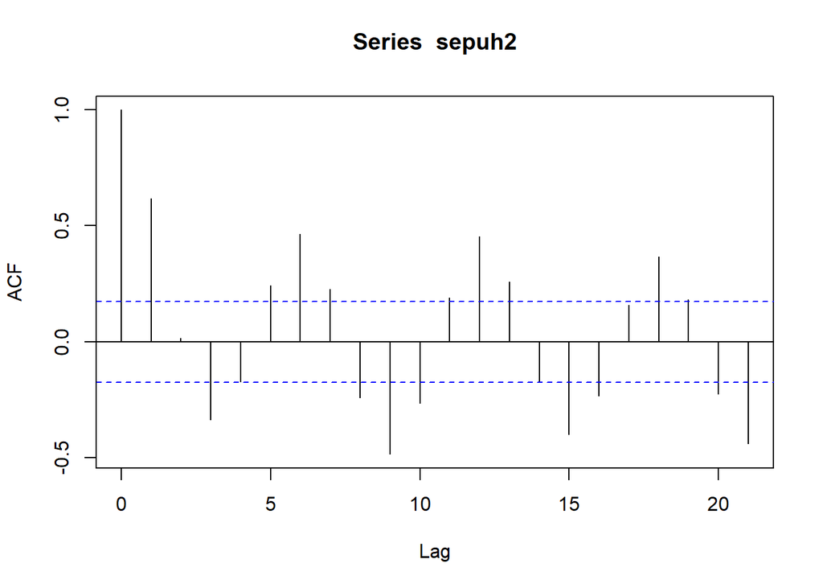

```r
acf(sepuh2)
```

Berdasarkan plot ACF, terlihat bahwa plot ACF pada data tersebut cenderung tails off dan membentuk gelombang sinus.

#Uji ADF

```r
adf.test(sepuh2)
```

```
##
##  Augmented Dickey-Fuller Test
##
## data:  sepuh2
## Dickey-Fuller = -3.759, Lag order = 4, p-value = 0.02327
## alternative hypothesis: stationary
```

$H_{0} : $ Data tidak stasioner dalam rataan $H_{1}:$ Data stasioner dalam rataan

Berdasarkan uji ADF tersebut, didapat p-value sebesar 0.02 yang lebih kecil dari taraf nyata 5% sehingga tolak $H_{0}$ dan menandakan bahwa data stasioner dalam rataan. Hal ini sesuai dengan hasil eksplorasi menggunakan plot time series dan plot ACF.

#Plot BoxCox

```r
index <- seq(1:126)
bc2 = boxcox(sepuh2~index, lambda = seq(-9,5,by=1))
```

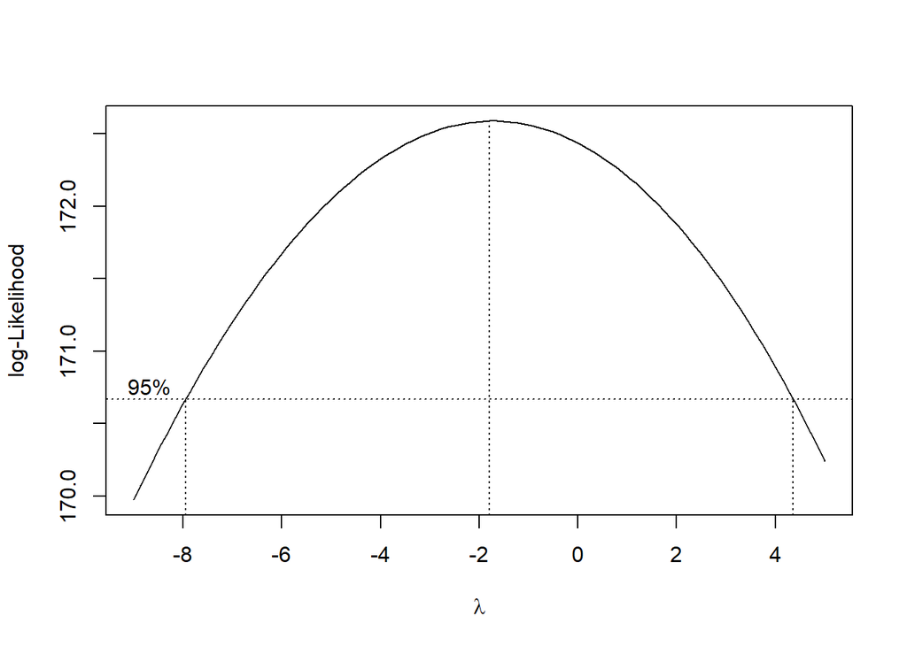

```r
#Nilai Rounded Lambda
lambda2 <- bc2$x[which.max(bc2$y)]
lambda2
```

```
## [1] -1.787879
```

```r
#Selang Kepercayaan
bc2$x[bc2$y > max(bc2$y) - 1/2 * qchisq(.95,1)]
```

```
##  [1] -7.86868687 -7.72727273 -7.58585859 -7.44444444 -7.30303030 -7.16161616
##  [7] -7.02020202 -6.87878788 -6.73737374 -6.59595960 -6.45454545 -6.31313131
## [13] -6.17171717 -6.03030303 -5.88888889 -5.74747475 -5.60606061 -5.46464646
## [19] -5.32323232 -5.18181818 -5.04040404 -4.89898990 -4.75757576 -4.61616162
## [25] -4.47474747 -4.33333333 -4.19191919 -4.05050505 -3.90909091 -3.76767677
## [31] -3.62626263 -3.48484848 -3.34343434 -3.20202020 -3.06060606 -2.91919192
## [37] -2.77777778 -2.63636364 -2.49494949 -2.35353535 -2.21212121 -2.07070707
## [43] -1.92929293 -1.78787879 -1.64646465 -1.50505051 -1.36363636 -1.22222222
## [49] -1.08080808 -0.93939394 -0.79797980 -0.65656566 -0.51515152 -0.37373737
## [55] -0.23232323 -0.09090909  0.05050505  0.19191919  0.33333333  0.47474747
## [61]  0.61616162  0.75757576  0.89898990  1.04040404  1.18181818  1.32323232
## [67]  1.46464646  1.60606061  1.74747475  1.88888889  2.03030303  2.17171717
## [73]  2.31313131  2.45454545  2.59595960  2.73737374  2.87878788  3.02020202
## [79]  3.16161616  3.30303030  3.44444444  3.58585859  3.72727273  3.86868687
## [85]  4.01010101  4.15151515  4.29292929
```

Gambar di atas menunjukkan nilai rounded value $\lambda$ optimum sebesar -1.78 dan pada selang kepercayaan 95% nilai memiliki batas bawah -7.86 dan batas atas 4.29. Selang tersebut memuat nilai satu sehingga dapat dikatakan bahwa data bangkitan stasioner dalam ragam.